# NYPD Shooting Incident Analysis

by Susan Qu

2025-06-18

## Executive Summary

This report analyzes NYPD shooting incident data across time periods to identify patterns and trends. It includes:

- Borough Analysis
  - Shooting incidents by Borough
  - Borough trends over time
- Incidens Overall by Year and Month
- Time of Day Analysis
- Predictive Model: Factors Contributing to Shooting Incidents
- Key Findings
- Potential Biases

## Borough Analysis

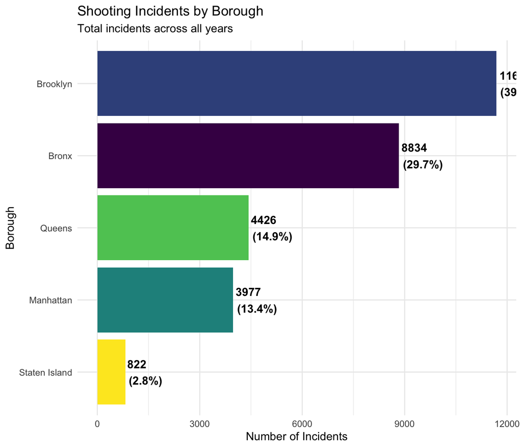

## Borough Trends Over Time

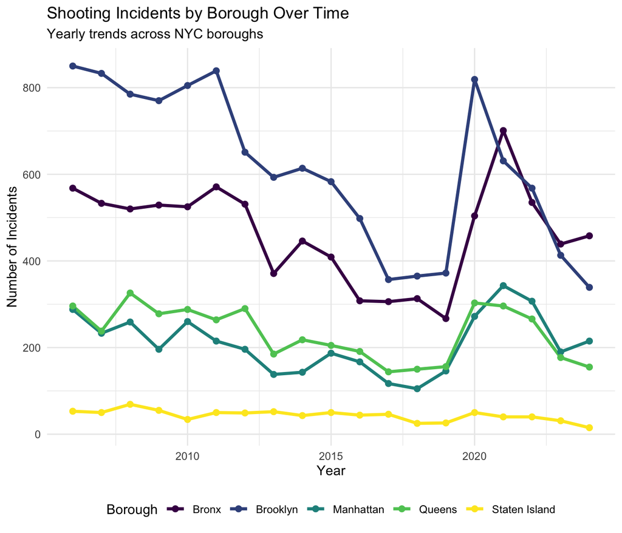

## Heatmap of incidents overall by year and month

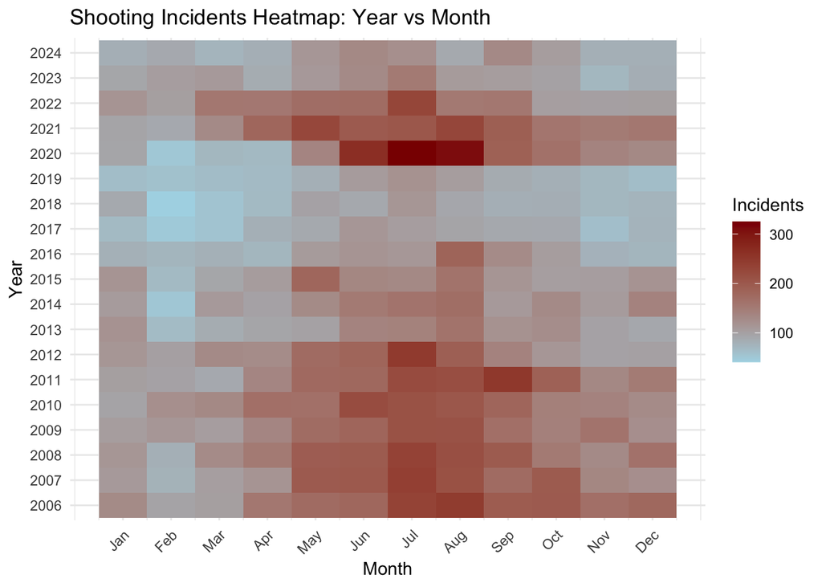

## Time of Day Analysis

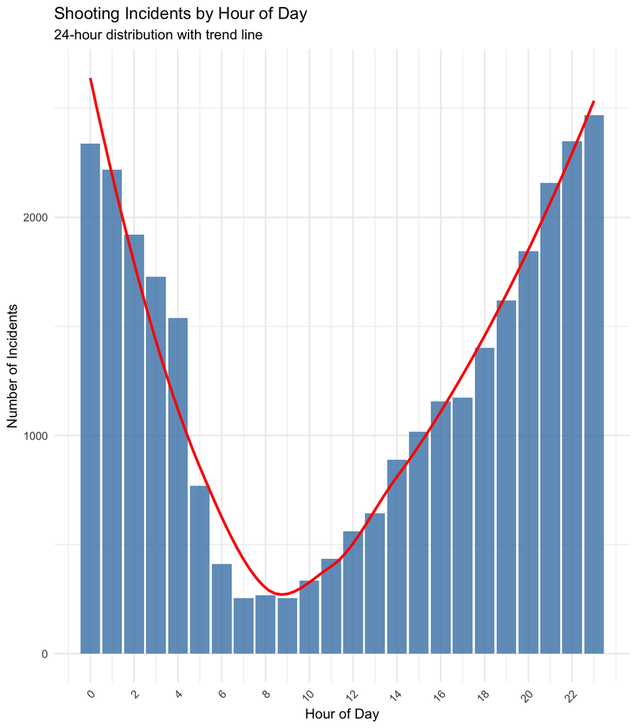

## Predictive Model: Factors Contributing to Shooting Incidents

```
## Model Data Summary:
```

```
##       Year          BORO              Season           TimeOfDay
##  Min.   :2006   Length:6228        Length:6228        Length:6228
##  1st Qu.:2010   Class :character   Class :character   Class :character
##  Median :2015   Mode  :character   Mode  :character   Mode  :character
##  Mean   :2015
##  3rd Qu.:2020
##  Max.   :2024
##    IsWeekend         IsSummer         MonthNum      IncidentCount
##  Min.   :0.0000   Min.   :0.0000   Min.   : 1.000   Min.   : 1.000
##  1st Qu.:0.0000   1st Qu.:0.0000   1st Qu.: 4.000   1st Qu.: 1.000
##  Median :0.0000   Median :0.0000   Median : 7.000   Median : 3.000
##  Mean   :0.4536   Mean   :0.2622   Mean   : 6.576   Mean   : 4.776
##  3rd Qu.:1.0000   3rd Qu.:1.0000   3rd Qu.: 9.000   3rd Qu.: 6.000
##  Max.   :1.0000   Max.   :1.0000   Max.   :12.000   Max.   :64.000
```

```
##
## Call:
## lm(formula = IncidentCount ~ BORO + Season + TimeOfDay + IsWeekend +
##     IsSummer + MonthNum + Year, data = model_data)
##
## Residuals:
##    Min     1Q Median     3Q    Max
## -8.859 -2.498 -0.702  1.501 53.265
##
## Coefficients: (1 not defined because of singularities)
##                     Estimate Std. Error t value Pr(>|t|)
## (Intercept)       208.441291  19.328811  10.784  < 2e-16 ***
## BOROBrooklyn        1.349525   0.148104   9.112  < 2e-16 ***
## BOROManhattan      -2.931909   0.160698 -18.245  < 2e-16 ***
## BOROQueens         -2.628420   0.157801 -16.657  < 2e-16 ***
## BOROStaten Island  -5.130137   0.214386 -23.929  < 2e-16 ***
## SeasonSpring        0.062641   0.193793   0.323  0.74653
## SeasonSummer        1.666564   0.159987  10.417  < 2e-16 ***
## SeasonWinter       -0.727571   0.180677  -4.027 5.72e-05 ***
## TimeOfDayEvening    3.088911   0.145062  21.294  < 2e-16 ***
## TimeOfDayMorning   -1.919810   0.173002 -11.097  < 2e-16 ***
## TimeOfDayNight      2.386795   0.144922  16.470  < 2e-16 ***
## IsWeekend          -1.745070   0.106835 -16.334  < 2e-16 ***
## IsSummer                  NA         NA      NA       NA
## MonthNum            0.069754   0.020593   3.387  0.00071 ***
## Year               -0.101138   0.009589 -10.547  < 2e-16 ***
## ---
## Signif. codes:  0 '***' 0.001 '**' 0.01 '*' 0.05 '.' 0.1 ' ' 1
##
## Residual standard error: 4.175 on 6214 degrees of freedom
## Multiple R-squared:  0.3218, Adjusted R-squared:  0.3203
## F-statistic: 226.8 on 13 and 6214 DF,  p-value: < 2.2e-16
```

```
##               Factor Coefficient
## 1  BOROStaten Island -5.13013732
## 2   TimeOfDayEvening  3.08891147
## 3      BOROManhattan -2.93190888
## 4         BOROQueens -2.62842014
## 5     TimeOfDayNight  2.38679511
## 6   TimeOfDayMorning -1.91980983
## 7          IsWeekend -1.74506999
## 8       SeasonSummer  1.66656443
## 9       BOROBrooklyn  1.34952455
## 10      SeasonWinter -0.72757074
## 11              Year -0.10113821
## 12          MonthNum  0.06975421
## 13      SeasonSpring  0.06264119
## 14          IsSummer          NA
```

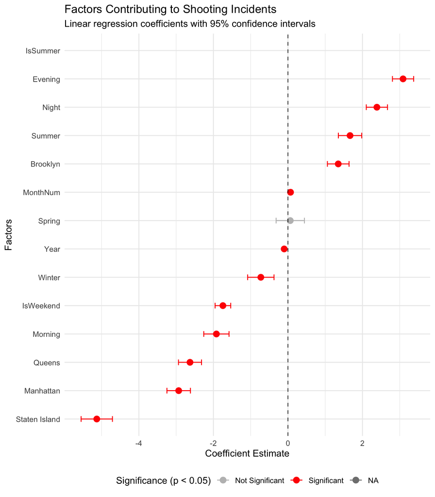

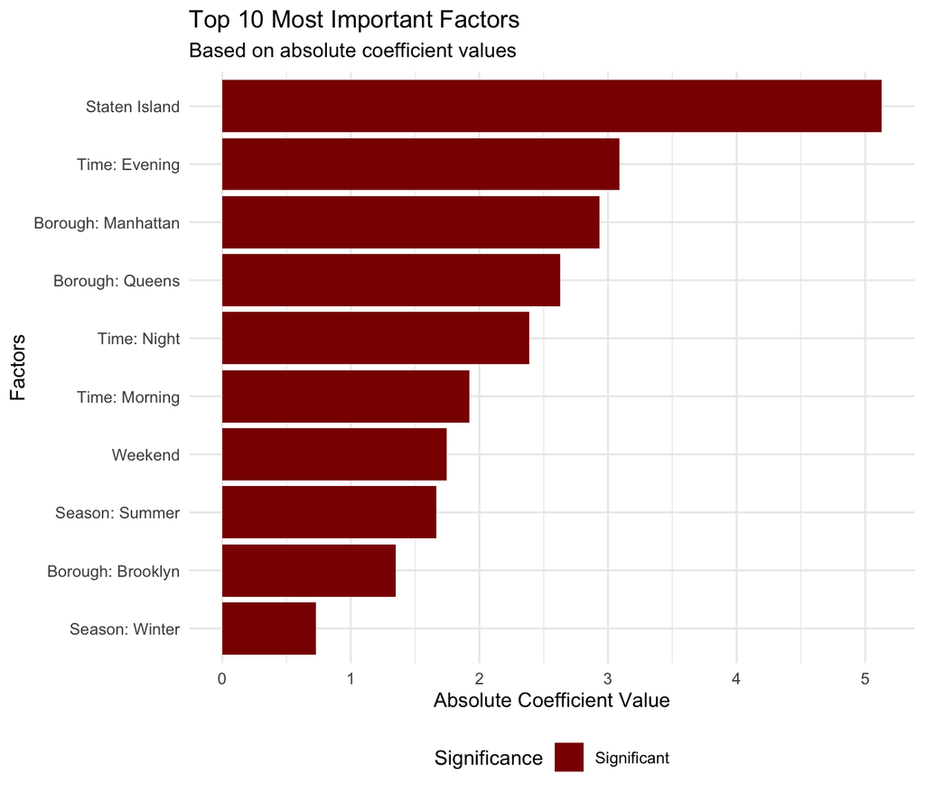

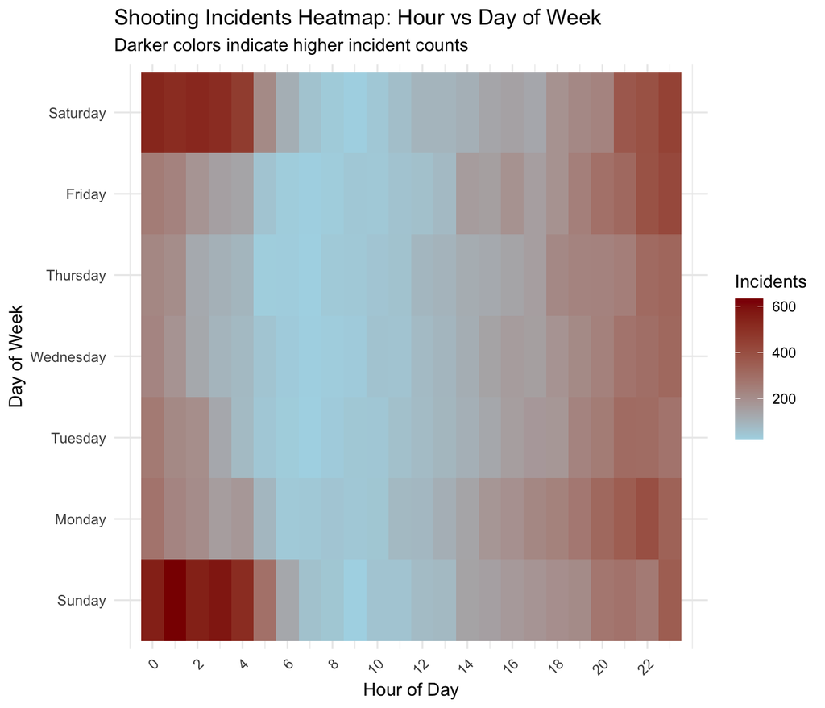

## Key Findings

The linear regression model identifies several significant factors contributing to shooting incidents:

1. **Borough Effects**: Different boroughs show varying baseline incident rates; for example, Brooklyn has the highest number of incidents, while Staten Island has the lowest.
2. **Seasonal Patterns**: Summer months typically see higher incident rates; incidents spike in July and August.
3. **Time of Day**: Evening and night hours show different patterns than daytime; incidents are more frequent after 6 PM, and peaks are observed around midnight.
4. **Temporal Trends**: Year-over-year changes in incident patterns; recent years have shown a decline in incidents.
5. **Weekend Effect**: Weekends may have different incident rates than weekdays; Saturday nights are particularly notable.

## Potential Biases

### **Reporting Bias**

- **Under-reporting**: Not all shooting incidents may be reported to police, particularly in communities with distrust of law enforcement. See [Economic and Policy Insights](https://www.osc.ny.gov/reports/concerning-growth-hate-crime-new-york-state#:~:text=6,victims'%20ability%20to%20report%20crimes).

### **Population Bias**

- **Demographic differences**: From the analysis, while Staten Island has the lowest number of incidents, it is important to consider that Staten Island has a significantly smaller population compared to other boroughs. This can skew the perception of safety and incident rates. Brooklyn is the most populous of New York City’s five boroughs, while Staten Island is the least populated. Brooklyn has over 2.6 million residents, whereas Staten Island has less than 500,000. See [NYC Population Data](https://www1.nyc.gov/site/planning/data-maps/nyc-population/population-facts.page) for more details.

## References

- NYPD Shooting Incident Data: [NYPD Data Portal](https://data.cityofnewyork.us/Public-Safety/NYPD-Shooting-Incident-Data-Historic-/qgea-i56i)
- NYC Population Data: [NYC Planning](https://www1.nyc.gov/site/planning/data-maps/nyc-population/population-facts.page)
- Economic and Policy Insights: [Hate Crime Report](https://www.osc.ny.gov/reports/concerning-growth-hate-crime-new-york-state#:~:text=6,victims'%20ability%20to%20report%20crimes)

## Github Link:

- repo: https://github.com/SusanQu/boulder_msds_ds_as_a_field